# 01. ITS2 preprocessing and method comparison — maxEE88

Cutadapt paired-end vs ITSxpress paired-end (QC20, maxEE 8/8)

2026-10-15

# 1 1. Dataset

## 1.1 분석 범위

- 입력: `q20_ee88_both_full`의 Cutadapt paired-end 및 ITSxpress paired-end DADA2 feature table과 UNITE v10 99% taxonomy
- metadata: 동일 run의 공통 sample sheet인 `q20_ee22_both_full` metadata를 사용하고, 각 maxEE88 feature table에 실제 존재하는 SampleID만 결합함
- 비교 단위: 두 방법에 모두 존재하는 동일 SampleID 83개
- phyloseq level: ASV count, 7개 taxonomy rank 및 동일 metadata
- filtering: taxonomy 정리, `Kingdom == Fungi`, zero-sum sample/taxon 제거만 적용함
- abundance threshold, singleton removal, rarefaction 및 decontam은 적용하지 않음
- PCoA: non-rarefied Species count에 pseudocount 0.5와 CLR을 적용한 Aitchison distance 사용함
- 방법 효과: 동일 SampleID 내 paired permutation을 적용한 PERMANOVA와 `betadisper`로 평가함

## 1.2 Sample info

| Item | N |
| --- | --- |
| Metadata samples | 83 |
| Common samples in both methods | 83 |
| Skin subjects | 2 |
| Skin Subject × Site units | 18 |
| Control sources | 3 |

| Method | Fungal_Samples | Fungal_ASVs | Total_Fungal_Reads | Method_Only_Samples |
| --- | --- | --- | --- | --- |
| Cutadapt | 83 | 1292 | 999983 | 0 |
| ITSxpress | 83 | 1221 | 541963 | 0 |

| Sample_Type | Control_Type | PCR_Cycle_Group | N |
| --- | --- | --- | --- |
| Control | Air swab | PCR1_33__PCR2_8 | 1 |
| Control | Air swab | PCR1_33__PCR2_10 | 1 |
| Control | Air swab | PCR1_35__PCR2_8 | 1 |
| Control | Air swab | PCR1_35__PCR2_10 | 1 |
| Control | Clean bench swab | PCR1_33__PCR2_8 | 1 |
| Control | Clean bench swab | PCR1_33__PCR2_10 | 1 |
| Control | Clean bench swab | PCR1_35__PCR2_8 | 1 |
| Control | Clean bench swab | PCR1_35__PCR2_10 | 1 |
| Control | Empty tube | PCR1_33__PCR2_8 | 1 |
| Control | Empty tube | PCR1_33__PCR2_10 | 1 |

[output cut: 6 more lines]

# 2 2. Phyloseq preprocessing

## 2.1 생성 및 taxonomy 검증

| Method | Stage | Samples | Taxa | Total_Reads |
| --- | --- | --- | --- | --- |
| Cutadapt | Imported ASV table | 83 | 1292 | 999983 |
| Cutadapt | Taxonomy cleaned | 83 | 1292 | 999983 |
| Cutadapt | Kingdom == Fungi retained | 83 | 1292 | 999983 |
| Cutadapt | Zero-sum samples/taxa removed | 83 | 1292 | 999983 |
| ITSxpress | Imported ASV table | 83 | 1221 | 541963 |
| ITSxpress | Taxonomy cleaned | 83 | 1221 | 541963 |
| ITSxpress | Kingdom == Fungi retained | 83 | 1221 | 541963 |
| ITSxpress | Zero-sum samples/taxa removed | 83 | 1221 | 541963 |

| Method | ASV | Kingdom | Phylum | Class | Order | Family | Genus | Species |
| --- | --- | --- | --- | --- | --- | --- | --- | --- |
| Cutadapt | 1292 | 1 | 7 | 27 | 73 | 180 | 296 | 429 |
| ITSxpress | 1221 | 1 | 6 | 30 | 87 | 222 | 394 | 598 |

## 2.2 Sample별 read 및 ASV 비교

| Method | Sample_Type | N | Min | Max | Median | Mean | SD |
| --- | --- | --- | --- | --- | --- | --- | --- |
| Cutadapt | Control | 12 | 241 | 6719 | 1615.5 | 2270.8 | 1774.1 |
| Cutadapt | True | 71 | 801 | 42692 | 14266 | 13700.5 | 8279.4 |
| ITSxpress | Control | 12 | 42 | 6053 | 1385 | 1682.2 | 1733 |
| ITSxpress | True | 71 | 111 | 16315 | 7542 | 7349 | 4124.3 |

| Metric | N_Pairs | Median_Cutadapt | Median_ITSxpress | P_value | P_adjust_BH |
| --- | --- | --- | --- | --- | --- |
| Read depth | 83 | 11397 | 6804 | 1.774201002185712e-14 | 3.548402004371423e-14 |
| Observed ASV | 83 | 43 | 44 | 0.003773555069021246 | 0.003773555069021246 |

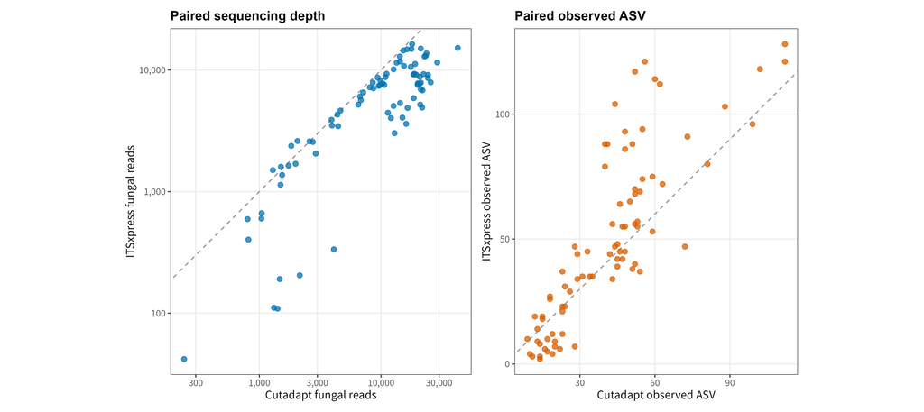

# 3 3. Beta diversity

## 3.1 Aitchison PCoA 및 paired method effect

| Distance | N_Samples | PERMANOVA_R2 | PERMANOVA_P | Betadisper_P | Procrustes_Correlation | PROTEST_P |
| --- | --- | --- | --- | --- | --- | --- |
| Aitchison (Species CLR, pseudocount 0.5) | 83 | 0.08673187797592051 | 0.001 | 0.019 | 0.9490452968717886 | 0.001 |

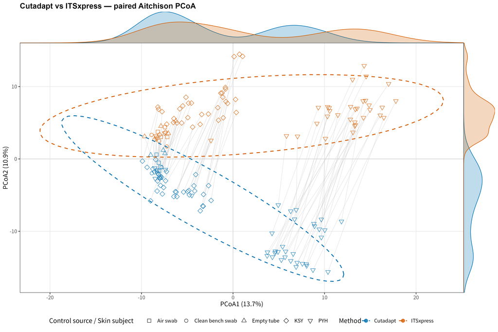

# 4 4. Taxonomic composition

## 4.1 Species overlap 및 paired abundance difference

- Spearman plot의 각 점은 sample 또는 ASV가 아니라, 동일 Species label로 집계한 뒤 공통 83개 sample의 relative abundance를 평균한 Species-level taxon임.
- 분홍색으로만 표시하던 주요 taxon은 RColorBrewer `Paired`와 `Dark2` 기반의 고정 색상을 적용하고 Species 이름을 직접 표시함.
- 표는 전체 Species overlap과 Top 14 Species의 paired abundance difference를 유지함.

| Item | N |
| --- | --- |
| Cutadapt detected Species | 429 |
| ITSxpress detected Species | 598 |
| Shared Species | 342 |
| Cutadapt only | 87 |
| ITSxpress only | 256 |

| Species | N_Pairs | Mean_Cutadapt | Mean_ITSxpress | Mean_Difference_ITSxpress_minus_Cutadapt | P_value | P_adjust_BH | Significant |
| --- | --- | --- | --- | --- | --- | --- | --- |
| Fungi k | 83 | 0.1337401930582224 | 0.002041578422570967 | -0.1316986146356515 | 8.232077861172561e-15 | 1.152490900564159e-13 | *** |
| Aureobasidium tremulum | 83 | 0.234894476320361 | 0 | -0.234894476320361 | 5.330808265775989e-13 | 3.731565786043192e-12 | *** |
| Malassezia restricta | 83 | 0.2783768826703787 | 0.3787277792409134 | 0.1003508965705347 | 2.038286497859522e-11 | 9.512003656677772e-11 | *** |
| Fungi sp | 83 | 0.000952922596327926 | 0.03199303815463549 | 0.03104011555830757 | 5.282724865618042e-11 | 1.809534124256976e-10 | *** |
| Nigrospora sp | 83 | 6.09930459673152e-05 | 0.02837056443847529 | 0.02830957139250797 | 7.75514624681561e-11 | 1.809534124256976e-10 | *** |
| Pleosporales sp | 83 | 0.002927059991929768 | 0.01674126196262863 | 0.01381420197069886 | 7.75514624681561e-11 | 1.809534124256976e-10 | *** |
| Cutaneotrichosporon debeurmannianum | 83 | 0.03189083423703654 | 0.07402807877226304 | 0.0421372445352265 | 9.324588479736105e-11 | 1.864917695947221e-10 | *** |
| Alternaria g | 83 | 0.01009122902815823 | 0.0327701055968992 | 0.02267887656874097 | 1.672125036828409e-10 | 2.926218814449715e-10 | *** |
| Rhodotorula mucilaginosa | 83 | 0.0179396081686889 | 0.04423018343909087 | 0.02629057527040197 | 1.02429508801569e-09 | 1.593347914691073e-09 | *** |
| Malassezia dermatis | 83 | 0.01274721807627902 | 0.02669866875402916 | 0.01395145067775014 | 1.051826013396945e-07 | 1.472556418755723e-07 | *** |

[output cut: 4 more lines]

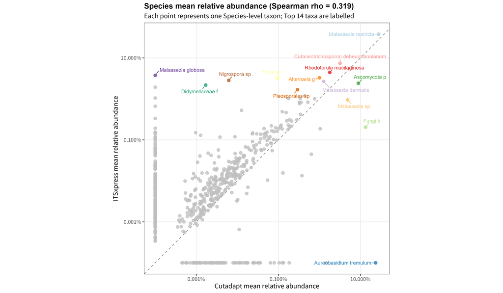

## 4.2 Sample별 Species composition

- 각 막대는 개별 SampleID 한 개이며 sample 평균으로 합치지 않음.
- Cutadapt와 ITSxpress를 각각 독립된 큰 panel로 제시하고, 내부에서 Skin subject 또는 control source와 PCR cycle 조건을 분리함.
- 두 방법에 동일한 Species 순서와 RColorBrewer 기반 색상을 적용함.
- HTML에는 전체 그림을 축소한 preview를 표시하며, SampleID와 taxon을 확대해서 볼 수 있는 고해상도 원본은 `Results/01_Preprocessing_maxEE88`에 별도로 저장함.

### 4.2.1 Cutadapt

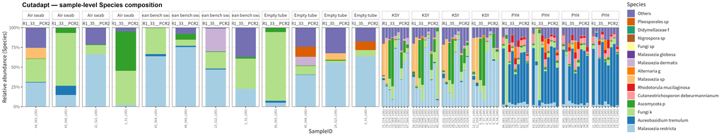

Cutadapt 고해상도 PNG 원본 열기

### 4.2.2 ITSxpress

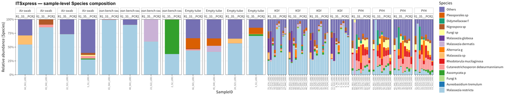

ITSxpress 고해상도 PNG 원본 열기

## 4.3 ASV sequence pattern 및 method 간 frequency 비교

- `Fungi_k`와 `Ascomycota_p`는 실제 Species명이 아니라 각각 Kingdom 또는 Phylum까지만 분류된 ASV에 부여한 fallback label임.
- 따라서 두 label 내부의 ASV 길이, adapter motif, prevalence와 abundance를 개별 서열 수준에서 다시 확인함.
- Cutadapt와 ITSxpress는 trimming 경계가 다르므로 완전 동일 서열뿐 아니라, 길이 100 bp 이상인 한쪽 ASV가 다른 쪽 ASV에 완전히 포함되는 exact-containment도 함께 평가함.
- 전체 재현 코드는 01_Preprocessing_maxEE88_diagnostic.R에 저장함.

### 4.3.1 미분류 ASV 길이와 Nextera motif

| Method | Taxon_Group | N_ASV | Median_Length | Q1_Length | Q3_Length | Min_Length | Max_Length | Median_GC | Median_Entropy | Nextera_full_ASV | Nextera_12mer_ASV | Total_Reads |
| --- | --- | --- | --- | --- | --- | --- | --- | --- | --- | --- | --- | --- |
| Cutadapt | Ascomycota_p | 110 | 296 | 86 | 356.5 | 36 | 418 | 55.13237626580992 | 0.9854796031796444 | 0 | 5 | 87506 |
| Cutadapt | Fungi_k | 325 | 111 | 71 | 286 | 33 | 399 | 49.17491749174918 | 0.9777410716621852 | 0 | 7 | 76428 |
| Cutadapt | Other_fungal_ASV | 857 | 346 | 314 | 362 | 125 | 516 | 47.56380510440835 | 0.9928056790948012 | 0 | 0 | 836049 |
| ITSxpress | Ascomycota_p | 23 | 162 | 149.5 | 172 | 140 | 222 | 62.84153005464481 | 0.96894733316262 | 0 | 0 | 11331 |
| ITSxpress | Fungi_k | 18 | 214.5 | 176 | 240.5 | 74 | 244 | 45.67478555346743 | 0.9891214168962428 | 0 | 0 | 1393 |
| ITSxpress | Other_fungal_ASV | 1180 | 191 | 161 | 208 | 56 | 369 | 50 | 0.983958784895532 | 0 | 0 | 529239 |

| Method | Taxon_Group | N_Group | P_Wilcoxon_vs_other_fungal | P_adjust_BH |
| --- | --- | --- | --- | --- |
| Cutadapt | Fungi_k | 325 | 9.974908590261843e-90 | 3.989963436104737e-89 |
| Cutadapt | Ascomycota_p | 110 | 1.677893433619939e-11 | 3.355786867239879e-11 |
| ITSxpress | Fungi_k | 18 | 0.05650372704564861 | 0.05650372704564861 |
| ITSxpress | Ascomycota_p | 23 | 0.0005426004270269694 | 0.0007234672360359592 |

- Cutadapt의 `Fungi_k`는 median 111 bp로, 분류된 다른 fungal ASV의 median 346 bp보다 현저히 짧음.
- Nextera 12-mer를 포함한 미분류 ASV는 12개, 합계 115 reads이며 모두 최대 prevalence 1 sample임. 완전한 19-mer Nextera sequence를 포함한 ASV는 0개임.
- 따라서 일부 짧은 ASV는 adapter-related artifact로 보이지만, 해당 reads 수가 작아 `Fungi_k`/`Ascomycota_p` 전체 abundance를 단독으로 설명하지는 못함.

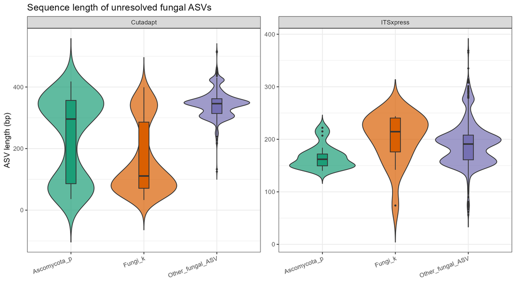

### 4.3.2 Nextera 비율과 미분류 taxon abundance

| Method | Taxon_Group | Nextera_Metric | Stratum | N | Spearman_rho | P_value | P_adjust_BH |
| --- | --- | --- | --- | --- | --- | --- | --- |
| Cutadapt | Ascomycota_p | Cleanup_match_percent | All samples | 83 | -0.01049494143822677 | 0.9249772933417776 | 0.9249772933417776 |
| Cutadapt | Ascomycota_p | Cleanup_match_percent | True only | 71 | 0.0732729711602951 | 0.5436736106482802 | 0.6867456134504593 |
| Cutadapt | Ascomycota_p | Raw_FastQC_percent | All samples | 83 | 0.0879266193694639 | 0.4292744881155002 | 0.5723659841540002 |
| Cutadapt | Ascomycota_p | Raw_FastQC_percent | True only | 71 | 0.203085177733065 | 0.08939411984044934 | 0.1650352981669834 |
| Cutadapt | Fungi_k | Cleanup_match_percent | All samples | 83 | 0.3964694831793555 | 0.0002068401057788931 | 0.00139254459802878 |
| Cutadapt | Fungi_k | Cleanup_match_percent | True only | 71 | 0.2154779969726712 | 0.07112375351399823 | 0.1422475070279965 |
| Cutadapt | Fungi_k | Raw_FastQC_percent | All samples | 83 | 0.3665482481277542 | 0.0006539019090538824 | 0.00313872916345863 |
| Cutadapt | Fungi_k | Raw_FastQC_percent | True only | 71 | 0.1709605211371376 | 0.1540162556532213 | 0.246426009045154 |
| ITSxpress | Ascomycota_p | Cleanup_match_percent | All samples | 83 | -0.3525732260806462 | 0.00107916268751075 | 0.00431665075004303 |
| ITSxpress | Ascomycota_p | Cleanup_match_percent | True only | 71 | -0.2340292824471222 | 0.04949123388675732 | 0.1079808739347432 |

[output cut: 6 more lines]

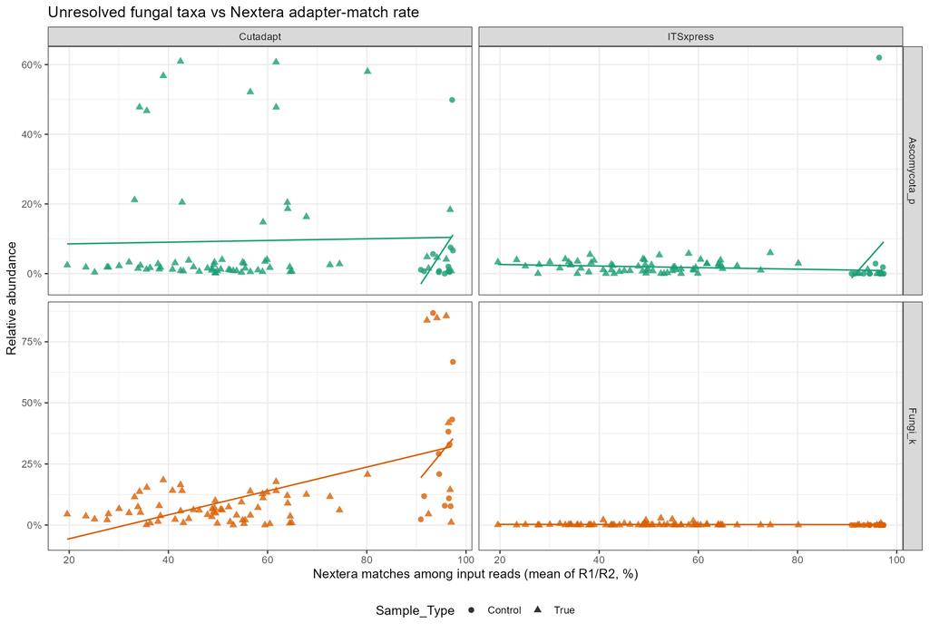

### 4.3.3 Cutadapt–ITSxpress ASV sequence frequency

| Metric | Value |
| --- | --- |
| Cutadapt ASVs | 1292 |
| ITSxpress ASVs | 1221 |
| Exact-identical ASV pairs | 0 |
| ITSxpress ASVs with &gt;=100-bp exact containment match | 736 |
| Matched ITSxpress ASV read fraction | 0.9550098438454284 |
| Matched ITSxpress ASV frequency vs Cutadapt frequency Spearman rho | 0.9239545809299968 |

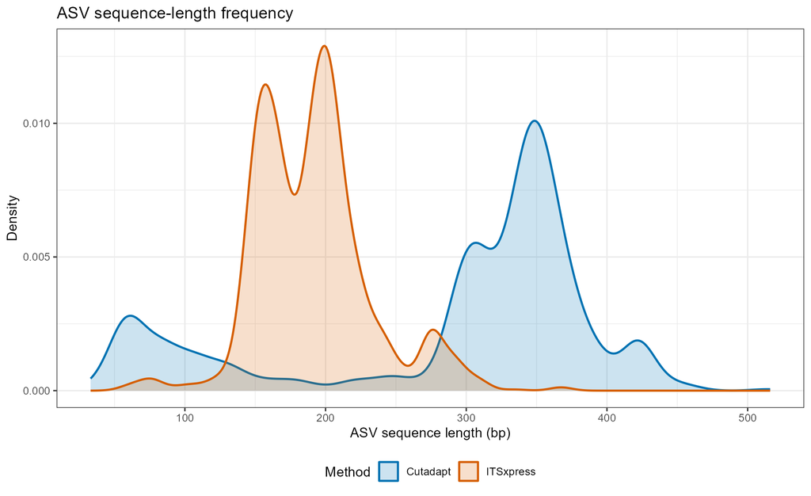

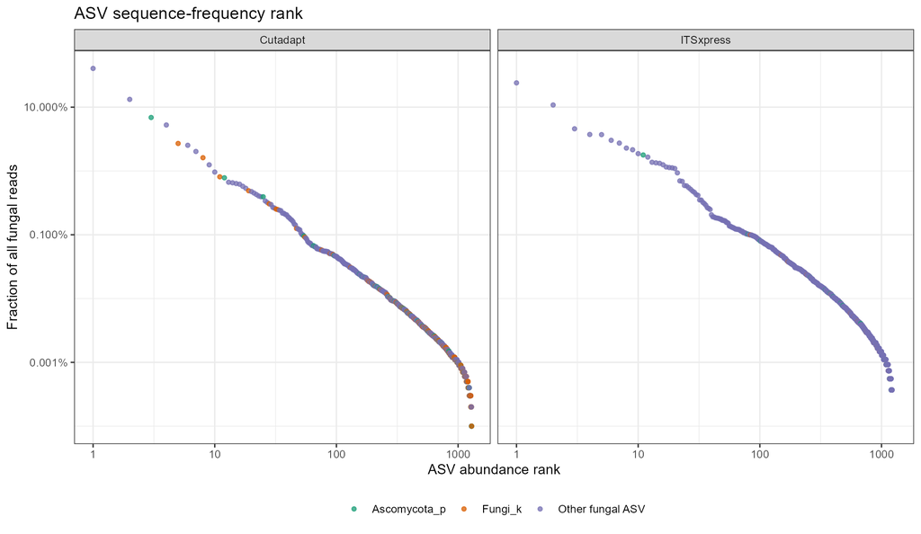

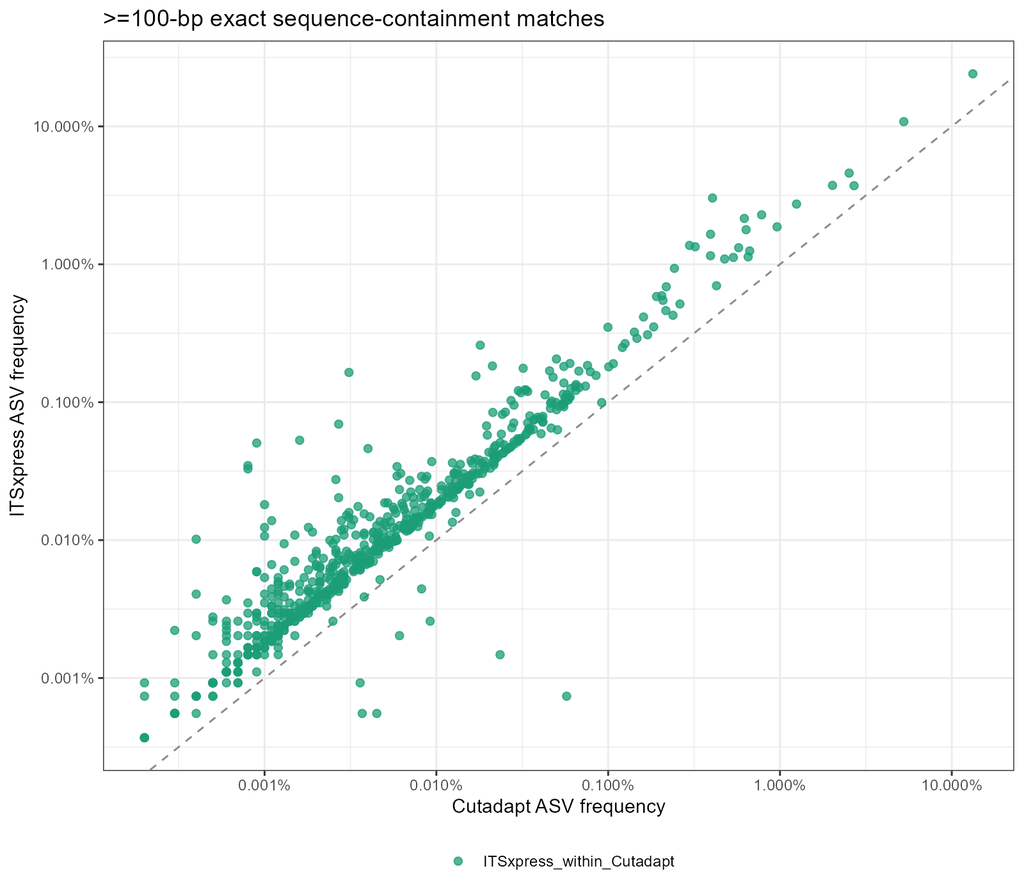

- 완전 동일한 ASV sequence pair가 없는 것은 두 방법의 trimming 경계 차이와 일치함.
- ITSxpress ASV 중 100 bp 이상 exact-containment로 Cutadapt ASV에 대응되는 서열은 736개이며, 이들이 ITSxpress fungal read의 95.5%를 차지함.
- 대응 ASV의 전체 read frequency 순위상관은 Spearman rho 0.924로, 주요 서열의 abundance ordering이 두 방법에서 얼마나 유지되는지 평가함.

# 5 5. 결론

- 동일한 83개 sample에서 Cutadapt와 ITSxpress phyloseq object를 생성함.
- 최종 fungal ASV는 Cutadapt 1292개, ITSxpress 1221개로 확인됨.
- 총 fungal read는 Cutadapt 999,983개, ITSxpress 541,963개로 확인됨.
- Paired Aitchison PERMANOVA의 method effect R2는 0.0867, p-value는 0.001로 확인됨.
- Procrustes correlation은 0.949, PROTEST p-value는 0.001로 확인됨.
- 상위 14 Species 중 paired Wilcoxon BH-adjusted p < 0.05인 taxon은 13개로 확인됨.

# 6 6. 한계점 및 향후 분석 예정

- 현재 비교는 `q20_ee88_both_full` 한 parameter 조합에 한정됨.
- Cutadapt와 ITSxpress가 서로 다른 sequence variant를 생성하므로 ASV identity를 직접 일치시키지 않고 동일 taxonomy label의 Species count로 집계하여 비교함.
- 미분류 taxon은 가장 낮은 확인 rank 기반 label로 보완되어 database resolution의 영향을 받음.
- Aitchison PCoA는 rarefaction 없이 수행했으며, pseudocount 0.5 선택에 따른 sensitivity는 수행하지 않음.
- abundance threshold와 singleton removal을 적용하지 않아 low-abundance ASV가 phyloseq object에 유지됨.
- decontam method와 contaminant removal은 적용하지 않음.
- 현재 단계의 paired method test는 library-level 비교이며, Skin biological unit의 반복 PCR 구조에 대한 biological inference를 목적으로 하지 않음.

향후 분석 우선순위:

1. 본 보고서에서 생성한 두 phyloseq object를 입력으로 동일한 Basic analysis를 수행함.
2. Skin sample은 Subject × Site × PCR 구조를 유지하고, control은 source별로 분리하여 두 방법의 alpha, beta 및 taxa 결과를 비교함.
3. Batch balance와 decontam method·threshold가 승인된 이후 두 방법에서 contamination profile의 일관성을 평가함.